# Proyecto clustering

#### Justificación del nstart

El parámetro nstart indica cuántas veces se ejecutará el algoritmo con diferentes inicializaciones aleatorias. Esto ayuda a encontrar una mejor solución.

Se usa ese valor de 25 para obtener con una sola corrida la distribución optima de nuestros grupos, es decir, que los clústers sean más compactos, homogéneos y mas separados de los otros con una inercia intraclases baja.

Es decir, una mayor cantidad de inicializaciones garantizará que los clusters sean mas compactos y separados entre si.

#### Grafico de la inercia total Intra-clases con nstart = 1 y luego con nstart = 25.

En el grafico se puede observar cómo la inercia total disminuye a medida que aumenta el número de clústeres (k).

```r
# Inicializar vectores para almacenar la inercia
k = 3
inertia_nstart_1 <- numeric(10)
inertia_nstart_25 <- numeric(10)

# Calcular inercia para nstart = 1
for (n in 1:10) {
  kmeans_result <- kmeans(scaled_data, centers = n, nstart = 1)
  inertia_nstart_1[n] <- kmeans_result$tot.withinss
}

# Calcular inercia para nstart = 25
for (n in 1:10) {
  kmeans_result <- kmeans(scaled_data, centers = n, nstart = 25)
  inertia_nstart_25[n] <- kmeans_result$tot.withinss
}
```

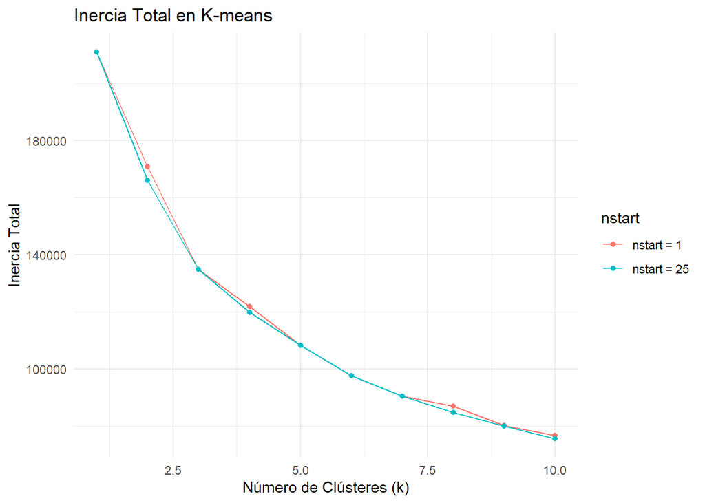

```r
# Crear un data frame para graficar
inertia_data <- data.frame(
  n = rep(1:10, 2),
  inertia = c(inertia_nstart_1, inertia_nstart_25),
  nstart = rep(c("nstart = 1", "nstart = 25"), each = 10)
)

# Graficar la inercia
ggplot(inertia_data, aes(x = n, y = inertia, color = nstart)) +
  geom_line() +
  geom_point() +
  labs(title = "Inercia Total en K-means",
       x = "Número de Clústeres (k)",
       y = "Inercia Total") +
  theme_minimal()
```

4. Aplicamos K-MEANS

```r
# Escalar las variables:
scaled_data <- scale(df[, c("capacity",
                            "occupancy")])

kmeans_result <- kmeans(scaled_data, centers = k, nstart = 25)
```

## Criterio de convergencia

Definimos un criterio para determinar cuándo el algoritmo debe detenerse. Esto puede basarse en la variación de los centroides o en un número máximo de iteraciones. En este caso, se basa en la variación de centroides.

El criterio de convergencia es esencial para garantizar que el algoritmo K-means funcione de manera eficiente y efectiva. Permite determinar cuándo se ha alcanzado una solución estable, optimiza el uso de recursos computacionales (no se cuelgue la PC) y ayuda a evaluar la calidad de los clústeres formados. Esto es crucial para obtener resultados significativos en el análisis de datos.

Inicializar variables para el control de convergencia:

```r
max_iter <- 100  # Número máximo de iteraciones
tolerance <- 1e-4  # Tolerancia para el cambio en los centroides
converged <- FALSE  # Variable para controlar la convergencia
```

El algoritmo itera hasta que se cumple el criterio de convergencia o se alcanza el número máximo de iteraciones:

```r
for (iter in 1:max_iter) {
  # Guardar los centroides anteriores
  old_centers <- kmeans_result$centers

  # Reasignar clusters
  kmeans_result <- kmeans(scaled_data, centers = old_centers, nstart = 1)

  # Calcular el cambio en los centroides
  center_shift <- sum(sqrt(rowSums((kmeans_result$centers - old_centers)^2)))

  # Verificar la convergencia
  if (center_shift < tolerance) {
    converged <- TRUE
    break
  }
}
```

```r
# Ver los resultados finales
if (converged) {
  print("El algoritmo ha convergido.")
} else {
  print("El algoritmo no ha convergido después del número máximo de iteraciones.")
}
```

```
## [1] "El algoritmo ha convergido."
```

Visualizamos los clusters:

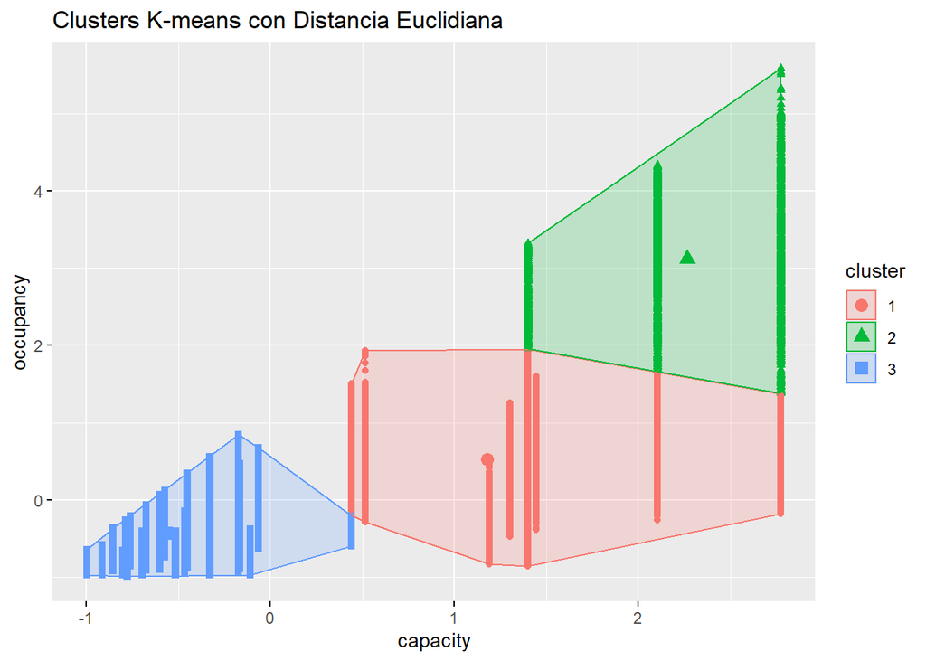

```r
library(factoextra)
fviz_cluster(kmeans_result, data = scaled_data,
             ellipse.type = "convex",
             geom = "point",
             show.clust.cent = TRUE,
             main = "Clusters K-means con Distancia Euclidiana")
```

Guardamos en un nuevo dataframe:

```r
df2 <- df[, c("capacity","occupancy", "mes", "dia", "hora")]
```

```r
# Instalar el paquete FactoMineR
#install.packages("FactoMineR")

# Cargar el paquete
library(FactoMineR)

modelo = PCA(df2, scale.unit =TRUE, ncp = 4, graph = FALSE)

print(modelo)
```

```
## **Results for the Principal Component Analysis (PCA)**
## The analysis was performed on 35169 individuals, described by 5 variables
## *The results are available in the following objects:
##
##    name               description
## 1  "$eig"             "eigenvalues"
## 2  "$var"             "results for the variables"
## 3  "$var$coord"       "coord. for the variables"
## 4  "$var$cor"         "correlations variables - dimensions"
## 5  "$var$cos2"        "cos2 for the variables"
## 6  "$var$contrib"     "contributions of the variables"
## 7  "$ind"             "results for the individuals"
## 8  "$ind$coord"       "coord. for the individuals"
## 9  "$ind$cos2"        "cos2 for the individuals"
## 10 "$ind$contrib"     "contributions of the individuals"
## 11 "$call"            "summary statistics"
## 12 "$call$centre"     "mean of the variables"
## 13 "$call$ecart.type" "standard error of the variables"
## 14 "$call$row.w"      "weights for the individuals"
## 15 "$call$col.w"      "weights for the variables"
```

```r
names(modelo$eig) = c("eigenvalue", "percent_of_variance", "cumulative_percent_variance")

print(modelo$eig)
```

```
##        eigenvalue percentage of variance cumulative percentage of variance
## comp 1  1.8073114               36.14623                          36.14623
## comp 2  1.0411201               20.82240                          56.96863
## comp 3  0.9975131               19.95026                          76.91889
## comp 4  0.9568074               19.13615                          96.05504
## comp 5  0.1972480                3.94496                         100.00000
## attr(,"names")
##  [1] "eigenvalue"                  "percent_of_variance"
##  [3] "cumulative_percent_variance" NA
##  [5] NA                            NA
##  [7] NA                            NA
##  [9] NA                            NA
## [11] NA                            NA
## [13] NA                            NA
## [15] NA
```

```r
print(modelo$var$coord)
```

```
##                Dim.1       Dim.2        Dim.3        Dim.4
## capacity  0.91445445 -0.10685741 -0.245794088  0.009148299
## occupancy 0.94908365 -0.01860290 -0.004231026 -0.002586880
## mes       0.08592597  0.71576399 -0.014526516 -0.692550019
## dia       0.05840177  0.71737671 -0.088164149  0.688535845
## hora      0.24398910  0.04907252  0.963896523  0.054862207
```

Grafico de distribución de variables:

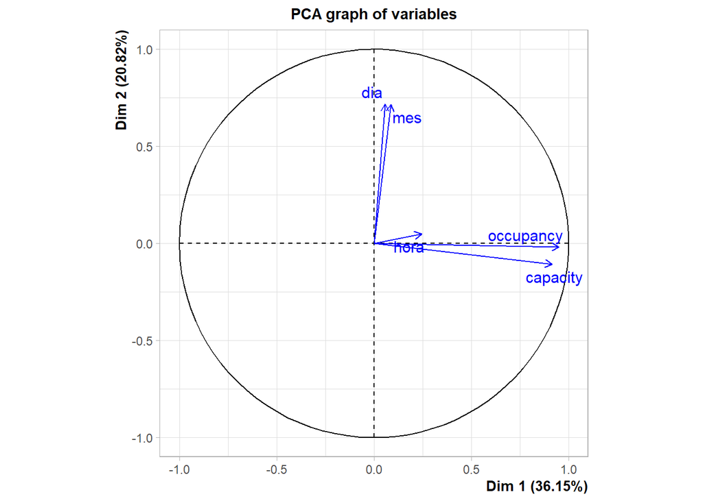

```r
plot(modelo, axes = c(1,2),
     choix = "var",
     col.var = "blue",
     new.plot = TRUE)
```

### Resumen teorico de los resultados de la tecnica utilizada (elementos de cada cluster, centroides)

1. CENTROIDES

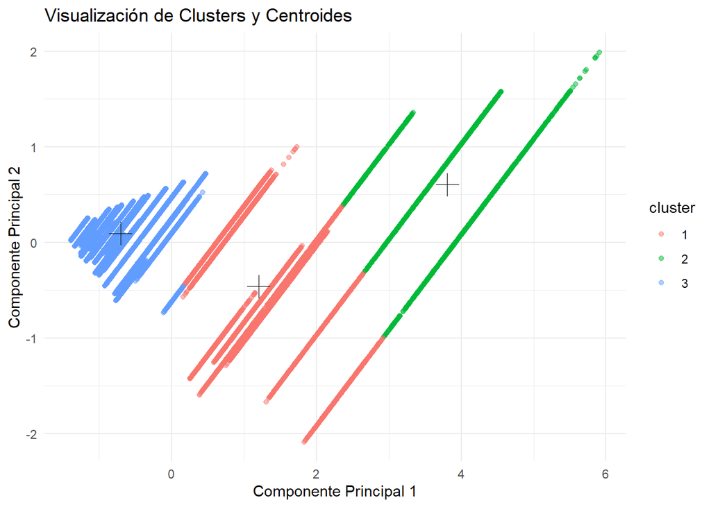

```r
# Calcular PCA
pca_result <- prcomp(scaled_data, center = TRUE, scale. = TRUE)

# Convertir los resultados a un data frame
pca_data <- as.data.frame(pca_result$x)

# Agregar la información de clusters
pca_data$cluster <- as.factor(kmeans_result$cluster)

# Calcular PCA para los centroides
centroids_pca <- predict(pca_result, newdata = kmeans_result$centers)

# Convertir los centroides a un data frame
centroids_df <- as.data.frame(centroids_pca)
centroids_df$cluster <- as.factor(1:nrow(centroids_df))  # Asignar un número de cluster

# Graficar los clusters y los centroides
ggplot(pca_data, aes(x = PC1, y = PC2, color = cluster)) +
  geom_point(alpha = 0.5) +
  geom_point(data = centroids_df, aes(x = PC1, y = PC2),
             color = "black", size = 5, shape = 3) +  # Centroides en negro
  labs(title = "Visualización de Clusters y Centroides",
       x = "Componente Principal 1",
       y = "Componente Principal 2") +
  theme_minimal()
```

Mostramos los centroides de cada cluster:

```r
# Obtener los índices de los clusters
df$cluster <- as.factor(kmeans_result$cluster)

# Calcular los centroides en la escala original
centroids_original <- aggregate(df[, c("capacity", "occupancy", "porcentaje_desocupado", "mes", "dia", "hora")],
                                by = list(cluster = df$cluster),
                                FUN = mean)

# Mostrar los centroides
print(centroids_original)
```

```
##   cluster  capacity occupancy porcentaje_desocupado      mes      dia     hora
## 1       1 2788.6182  986.8045              61.82243 10.86009 3.961729 43160.73
## 2       2 4075.0158 2700.1042              32.72833 10.99442 4.058605 47554.34
## 3       3  732.5466  357.6645              48.88810 10.87858 3.928168 43865.05
```

2. Cálculo de la Matriz de Distancias:

Para el algoritmo K-means, no es necesario calcular la matriz de distancias antes de aplicar el algoritmo. K-means maneja el cálculo de distancias internamente, lo que lo hace más eficiente y directo.

Intente hacerlo, pero al ser grande el conjunto de datos, al realizar los calculos, la PC se me quedó colgada.

#### DESCRIPCION DE CADA CLUSTER

```r
# 1. Obtener los clusters
clusters <- kmeans_result$cluster

# 2. Agregar los clusters al DataFrame
df_copy$cluster <- clusters

# 3. Ver el DataFrame con la nueva columna de clusters
head(df_copy)
```

```
##   system_code_number capacity occupancy     mes    dia        hora hora_num
## 1        BHMBCCMKT01      577        61 octubre martes  7H 59M 42S        7
## 2        BHMBCCMKT01      577        64 octubre martes  8H 25M 42S        8
## 3        BHMBCCMKT01      577        80 octubre martes  8H 59M 42S        8
## 4        BHMBCCMKT01      577       107 octubre martes  9H 32M 46S        9
## 5        BHMBCCMKT01      577       150 octubre martes  9H 59M 48S        9
## 6        BHMBCCMKT01      577       177 octubre martes 10H 26M 49S       10
##   hour porcentaje_desocupado cluster
## 1    7                 89.43       3
## 2    8                 88.91       3
## 3    8                 86.14       3
## 4    9                 81.46       3
## 5    9                 74.00       3
## 6   10                 69.32       3
```

```r
# Eliminamos system_code_number
df_copy <- subset(df_copy, select = -system_code_number)

# Convertir variables categóricas a factores y luego a numéricas
df_copy$mes <- as.numeric(factor(df_copy$mes, levels = c("enero", "febrero", "marzo", "abril", "mayo", "junio", "julio", "agosto", "septiembre", "octubre", "noviembre", "diciembre")))
df_copy$dia <- as.numeric(factor(df_copy$dia, levels = c("domingo", "lunes", "martes", "miércoles", "jueves", "viernes", "sábado")))
df_copy$hora <- as.numeric(df_copy$hora, units = "secs")

head(df_copy)
```

```
##   capacity occupancy mes dia  hora hora_num hour porcentaje_desocupado cluster
## 1      577        61  10   3 28782        7    7                 89.43       3
## 2      577        64  10   3 30342        8    8                 88.91       3
## 3      577        80  10   3 32382        8    8                 86.14       3
## 4      577       107  10   3 34366        9    9                 81.46       3
## 5      577       150  10   3 35988        9    9                 74.00       3
## 6      577       177  10   3 37609       10   10                 69.32       3
```

Comparamos los valores medios de cada cluster:

```r
summary_by_cluster <- aggregate(. ~ cluster, data = df_copy, FUN = mean, na.rm = TRUE)
print(summary_by_cluster)
```

```
##   cluster  capacity occupancy      mes      dia     hora hora_num     hour
## 1       1 2788.6182  986.8045 10.86009 3.961729 43160.73 11.55113 11.55113
## 2       2 4075.0158 2700.1042 10.99442 4.058605 47554.34 12.76884 12.76884
## 3       3  732.5466  357.6645 10.87858 3.928168 43865.05 11.74017 11.74017
##   porcentaje_desocupado
## 1              61.82243
## 2              32.72833
## 3              48.88810
```

# Diferencias entre clusters

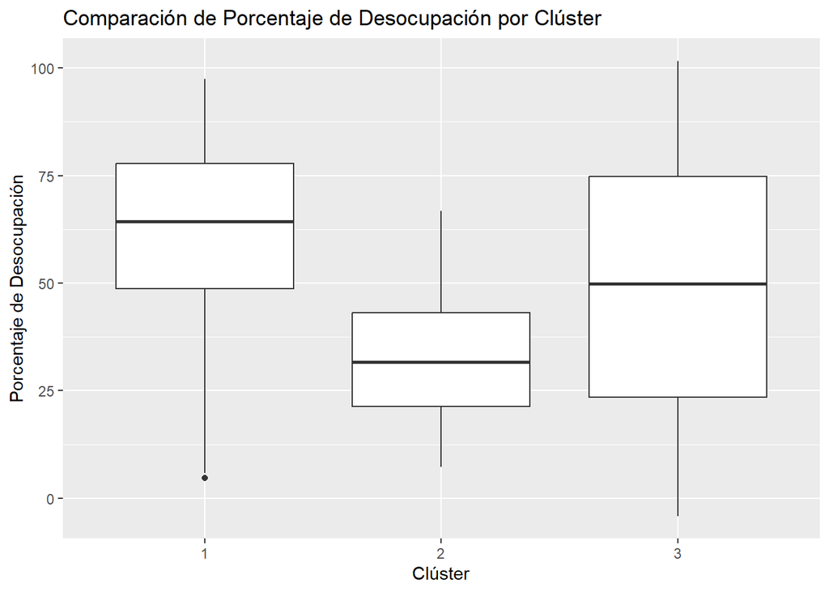

```r
library(ggplot2)

ggplot(df_copy, aes(x = factor(cluster), y = porcentaje_desocupado)) +
  geom_boxplot() +
  labs(title = "Comparación de Porcentaje de Desocupación por Clúster",
       x = "Clúster",
       y = "Porcentaje de Desocupación")
```

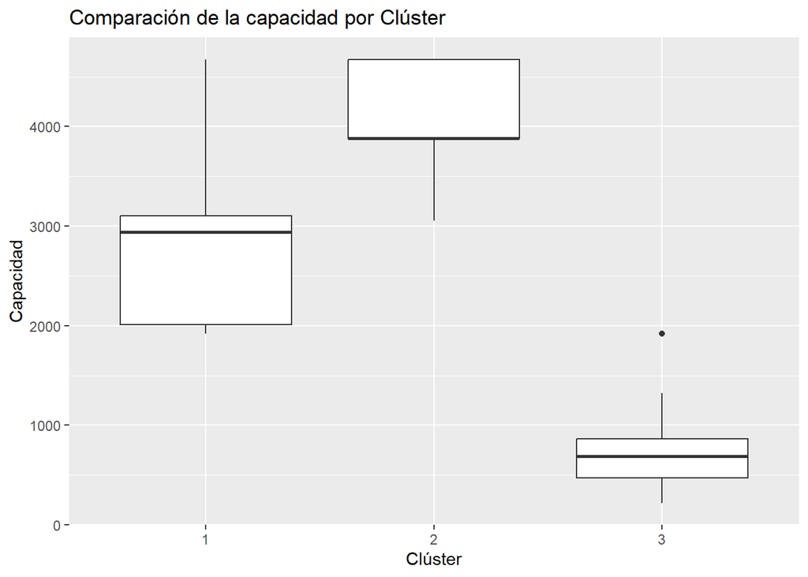

```r
ggplot(df_copy, aes(x = factor(cluster), y = capacity)) +
  geom_boxplot() +
  labs(title = "Comparación de la capacidad por Clúster",
       x = "Clúster",
       y = "Capacidad")
```

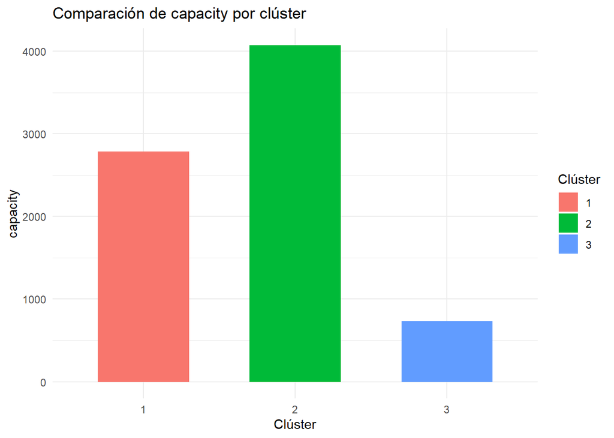

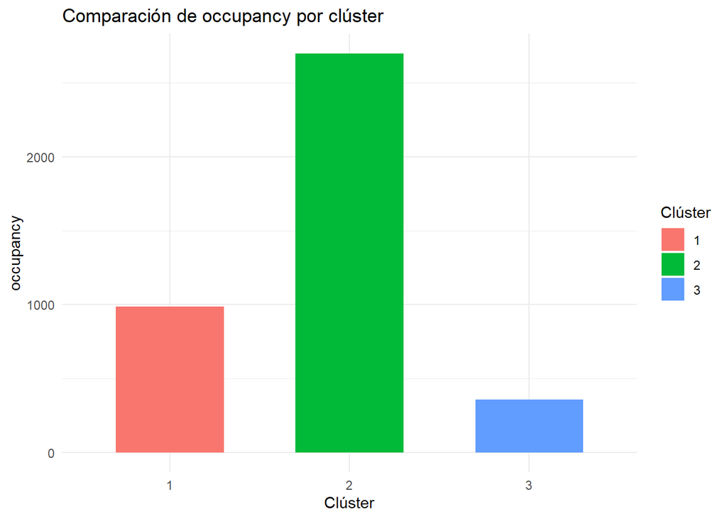

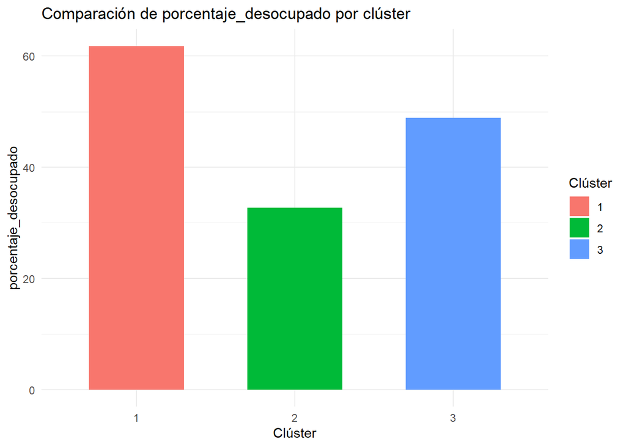

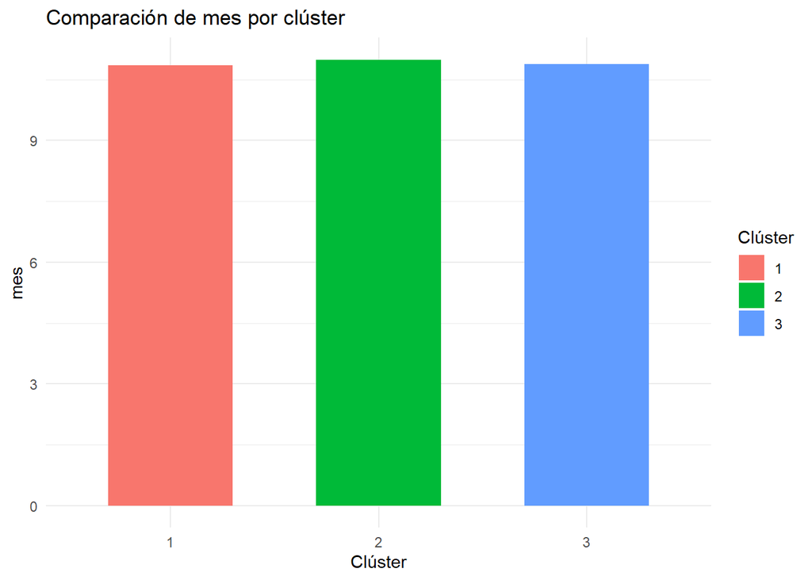

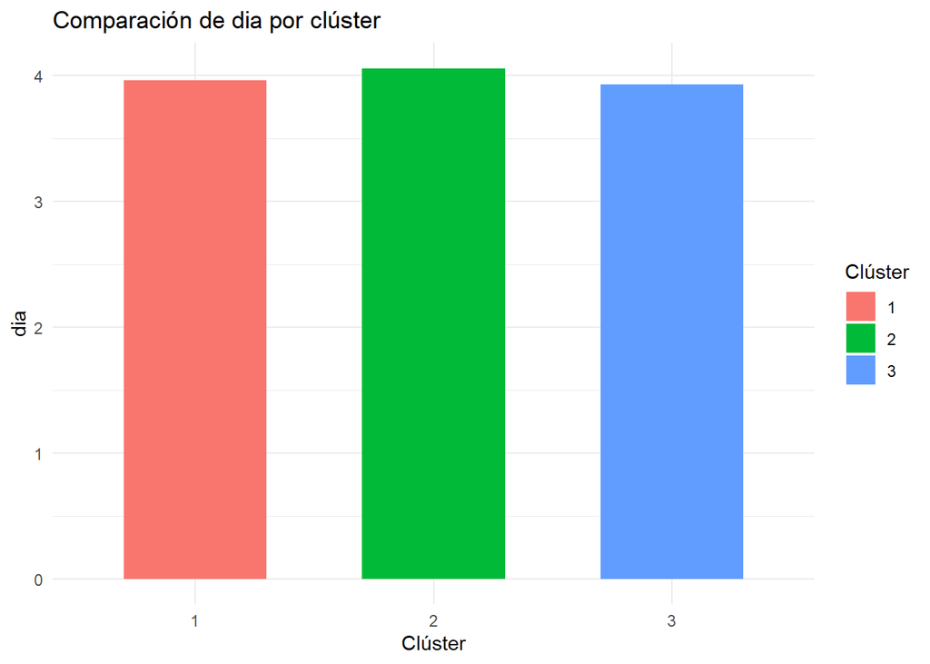

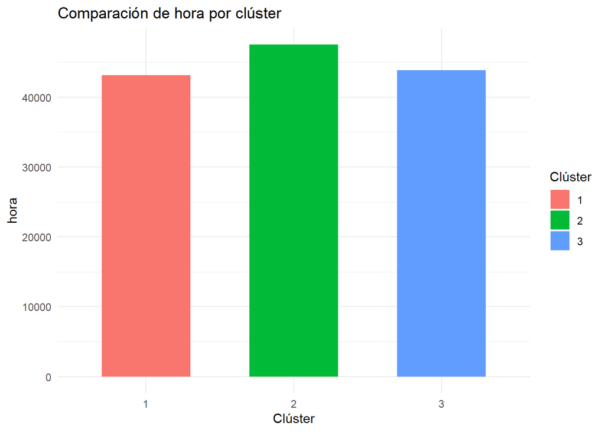

```r
# Lista de variables a graficar
variables <- c("capacity", "occupancy", "porcentaje_desocupado", "mes", "dia", "hora")

# Graficar cada variable por separado
for (var in variables) {
  p <- ggplot(summary_by_cluster, aes_string(x = "factor(cluster)", y = var, fill = "factor(cluster)")) +
    geom_bar(stat = "identity", width = 0.6) +
    labs(title = paste("Comparación de", var, "por clúster"),
         x = "Clúster", y = var, fill = "Clúster") +
    theme_minimal()
  print(p)
}
```

Visualizar los clústeres en un gráfico de dispersión:

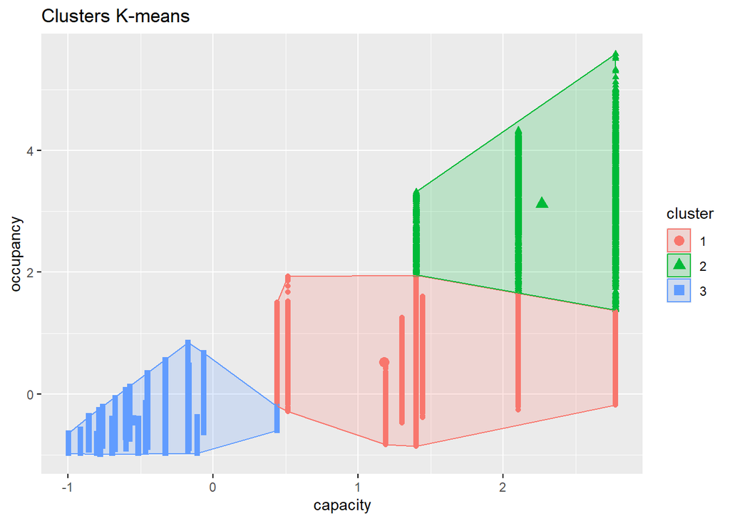

```r
library(factoextra)

fviz_cluster(kmeans_result, data = scaled_data,
             ellipse.type = "convex",
             geom = "point",
             show.clust.cent = TRUE,
             main = "Clusters K-means")
```

Gráfico de dispersión para capacidad y ocupación por clúster

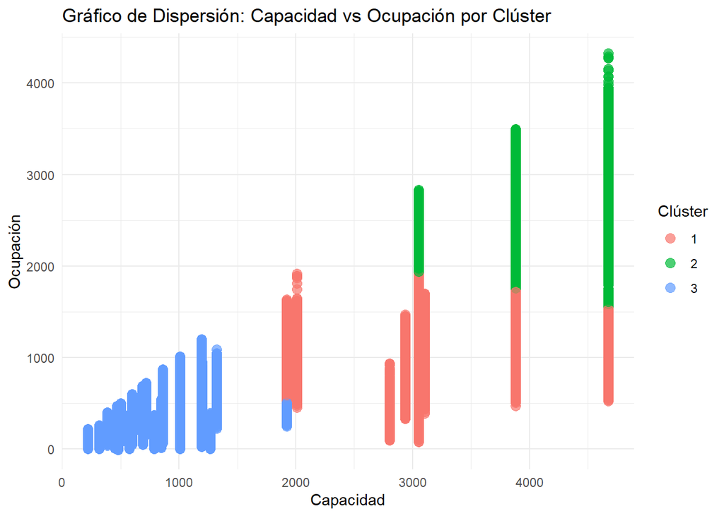

```r
ggplot(df_copy, aes(x = capacity, y = occupancy, color = factor(cluster))) +
  geom_point(size = 3, alpha = 0.7) +
  labs(title = "Gráfico de Dispersión: Capacidad vs Ocupación por Clúster",
       x = "Capacidad",
       y = "Ocupación",
       color = "Clúster") +
  theme_minimal()
```

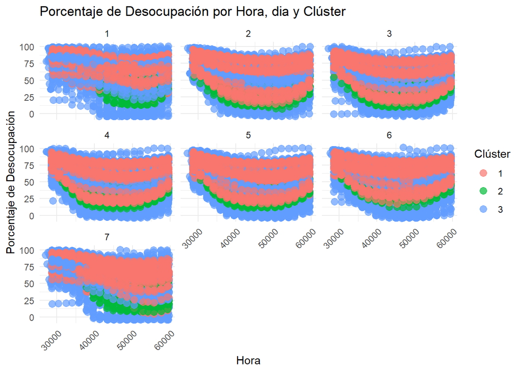

```r
ggplot(df_copy, aes(x = hora, y = porcentaje_desocupado, color = factor(cluster))) +
  geom_point(size = 3, alpha = 0.7) +  # Ajustar el tamaño y la transparencia de los puntos
  facet_wrap(~ dia) +  # Crear un panel para cada día
  labs(title = "Porcentaje de Desocupación por Hora, dia y Clúster",
       x = "Hora",
       y = "Porcentaje de Desocupación",
       color = "Clúster") +
  theme_minimal() +
  theme(axis.text.x = element_text(angle = 45, hjust = 1))  # Rotar etiquetas del eje x
```

### Relacion entre la hora, mes, dia de la semana y la cantidad de puestos desocupados

```r
head(df_copy)
```

```
##   capacity occupancy mes dia  hora hora_num hour porcentaje_desocupado cluster
## 1      577        61  10   3 28782        7    7                 89.43       3
## 2      577        64  10   3 30342        8    8                 88.91       3
## 3      577        80  10   3 32382        8    8                 86.14       3
## 4      577       107  10   3 34366        9    9                 81.46       3
## 5      577       150  10   3 35988        9    9                 74.00       3
## 6      577       177  10   3 37609       10   10                 69.32       3
```

```r
# Convertir variables categóricas a numéricas
sapply(df_copy, class)
```

```
##              capacity             occupancy                   mes
##             "integer"             "integer"             "numeric"
##                   dia                  hora              hora_num
##             "numeric"             "numeric"             "numeric"
##                  hour porcentaje_desocupado               cluster
##             "numeric"             "numeric"             "integer"
```

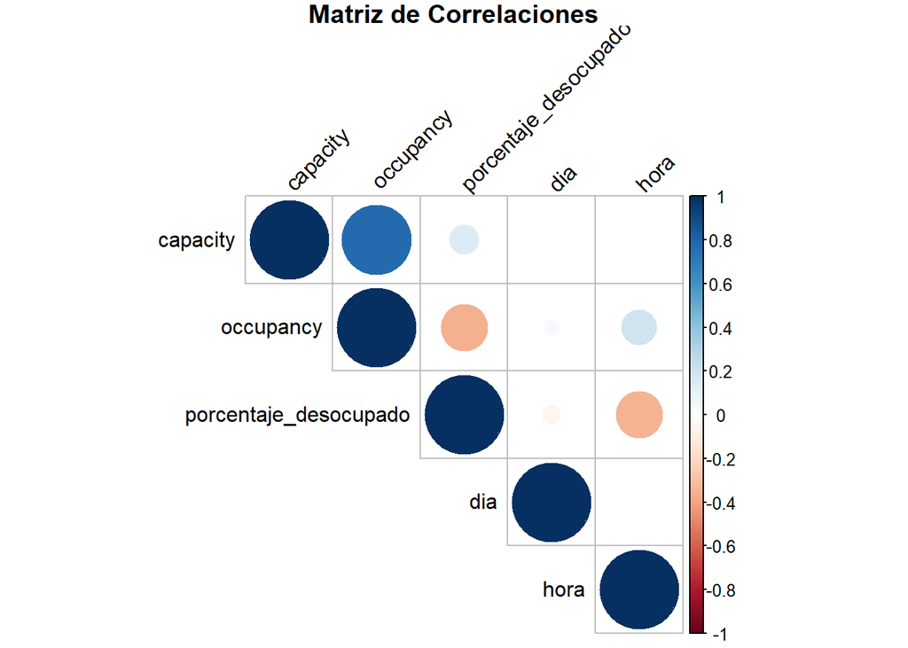

```r
# Seleccionar solo las columnas numéricas
df_numeric <- df_copy[, c("capacity", "occupancy", "porcentaje_desocupado", "dia", "hora")]

# Calcular la matriz de correlaciones
correlation_matrix <- cor(df_numeric)

#install.packages("corrplot")
library(corrplot)
# Visualizar la matriz de correlaciones
corrplot(correlation_matrix, method = "circle", type = "upper",
         tl.col = "black", tl.srt = 45,
         title = "Matriz de Correlaciones",
         mar = c(0, 0, 1, 0))
```